# R Notebook

```r
##Three different room_types were studied and each of their relative frequency is calculated to find their individual share
train %>% group_by(room_type) %>% select(room_type) %>% unique()
```

| room_type |
| --- |
| Entire home/apt |
| Private room |
| Shared room |

```r
count(train, room_type) %>% mutate(relative_freq = (n/sum(n)))
```

|  | room_type | n | relative_freq |
| --- | --- | --- | --- |
| 1 | Entire home/apt | 41310 | 0.55740713 |
| 2 | Private room | 30638 | 0.41340692 |
| 3 | Shared room | 2163 | 0.02918595 |

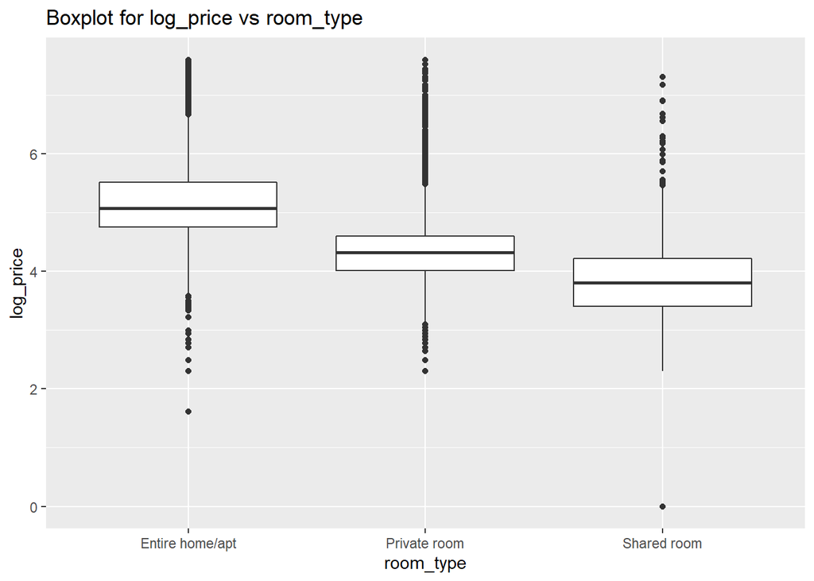

```r
##Those 3 kinds of room_types were studied through the use of boxplot to see their relationship with log_price
ggplot(train, aes(x= room_type, y=log_price))+geom_boxplot()+ ggtitle("Boxplot for log_price vs room_type")
```

```r
library(vcd)
```

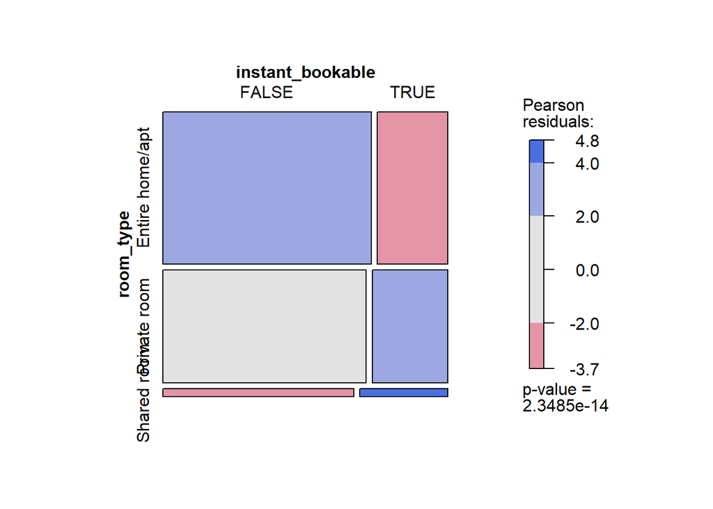

```r
mosaic(~room_type + instant_bookable, data = train, shade = TRUE)
```

From above mosaic plot we see, the two-tiles shaped deep blue correspond to only one cell having shared room_type and true instant_bookable whose residuals are greater than +4 indicating much greater frequency in this cell than would be found if the hypothesis of independence. The two-tile shaped having shared room_type with false instant_bookable and entire home/apt room_type with true instant_bookable corresponds to the residuals between -2.0 and -3.7 which indicates the combination is extremely rare under the hypothesis of independence.

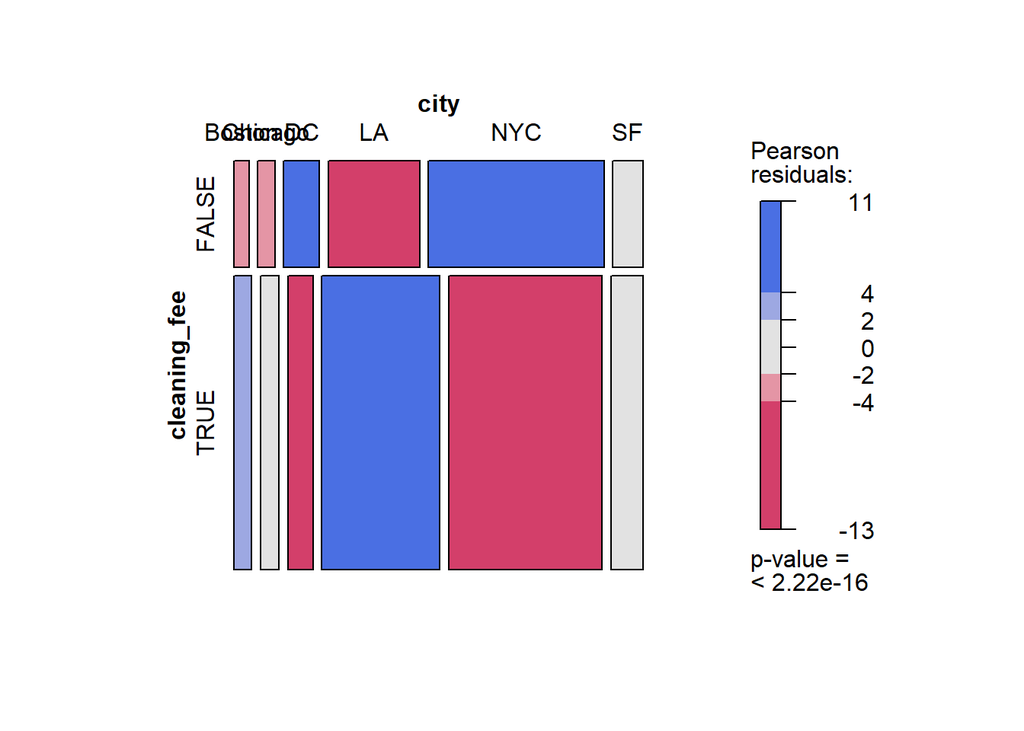

```r
library(vcd)
mosaic(~cleaning_fee + city, data = train, shade = TRUE)
```

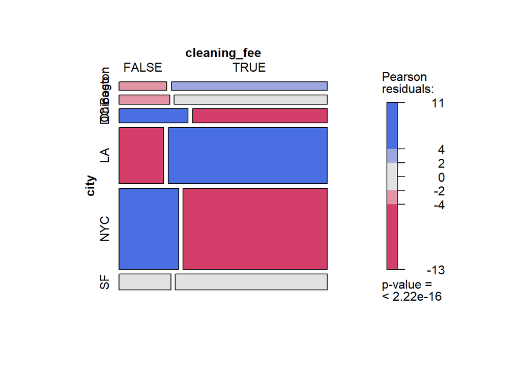

```r
mosaic(~city + cleaning_fee, data = train, shade = TRUE)
```

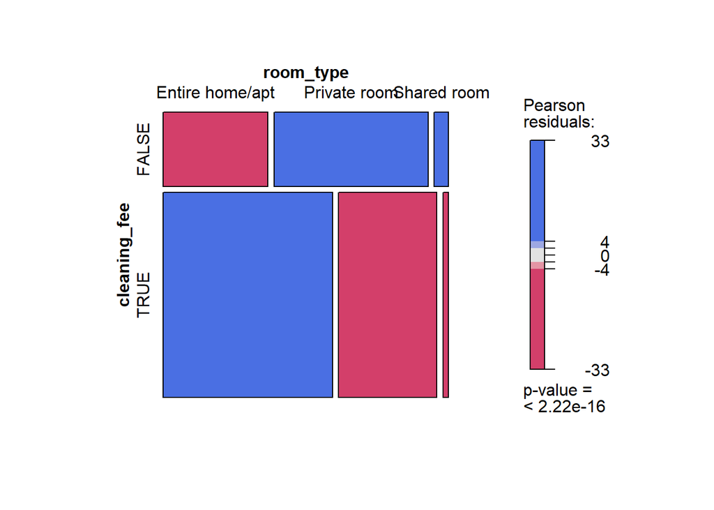

```r
##similar case like above
mosaic(~cleaning_fee + room_type, data = train, shade = TRUE)
```

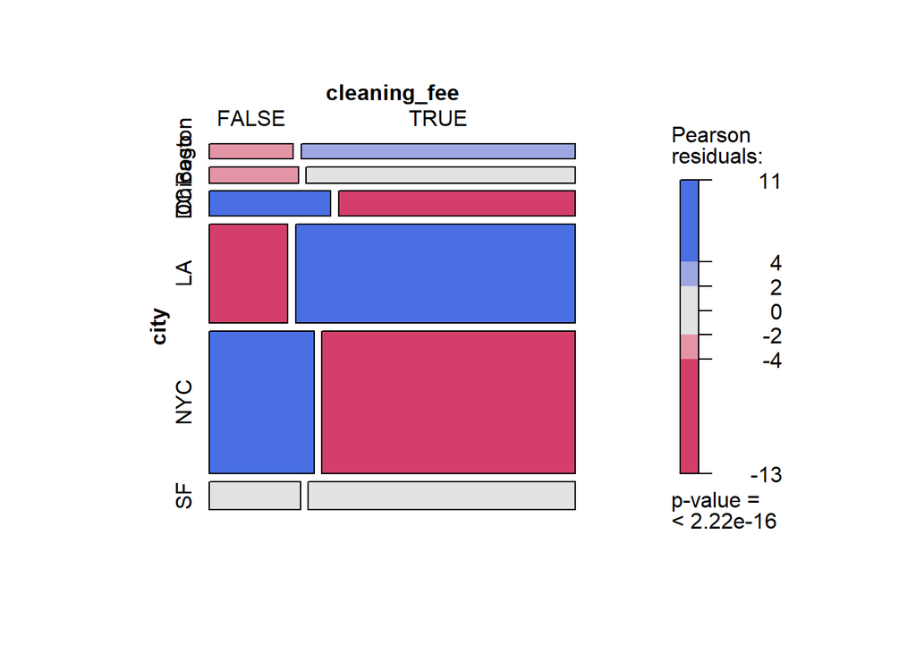

```r
#similar case like above
mosaic(~city + cleaning_fee, data = train, shade = TRUE)
```

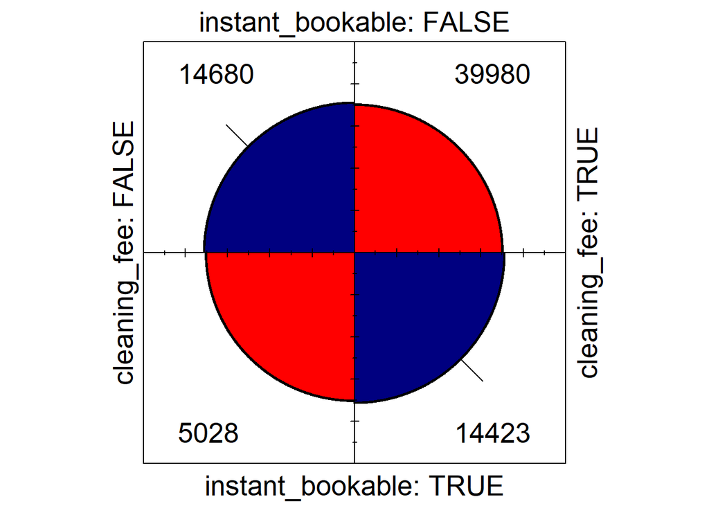

```r
##these variables are highly significant
fourfold(xtabs(~ instant_bookable + cleaning_fee, data = train))
```

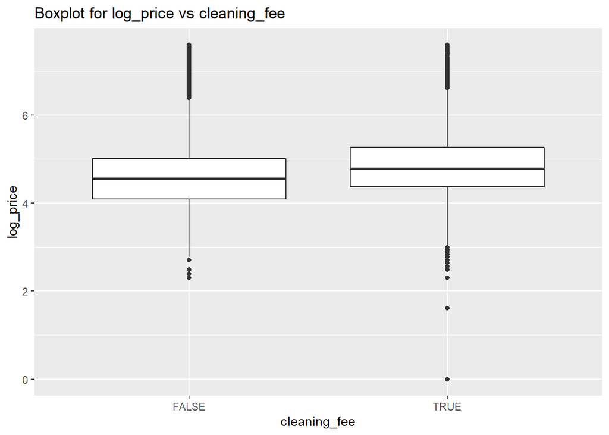

```r
##Those two conditions of cleaning fee(i.e. either yes or no) were studied through the use of boxplot to see their relationship with log_price

ggplot(train, aes(x= cleaning_fee, y=log_price))+geom_boxplot()+ ggtitle("Boxplot for log_price vs cleaning_fee")
```

```r
train %>% group_by(bedrooms) %>% select(bedrooms) %>% unique()
```

| bedrooms |
| --- |
| 1 |
| 3 |
| 2 |
| 0 |
| 4 |
| NA |
| 5 |
| 6 |
| 7 |
| 8 |

[output cut: 2 more lines]

```r
count(train, bedrooms) %>% mutate(relative_freq = (n/sum(n)))
```

|  | bedrooms | n | relative_freq |
| --- | --- | --- | --- |
| 1 | 0 | 6715 | 0.0906073322 |
| 2 | 1 | 49784 | 0.6717491331 |
| 3 | 2 | 11351 | 0.1531621487 |
| 4 | 3 | 4309 | 0.0581425160 |
| 5 | 4 | 1330 | 0.0179460539 |
| 6 | 5 | 355 | 0.0047901121 |
| 7 | 6 | 106 | 0.0014302870 |
| 8 | 7 | 38 | 0.0005127444 |
| 9 | 8 | 14 | 0.0001889058 |
| 10 | 9 | 8 | 0.0001079462 |

[output cut: 2 more lines]

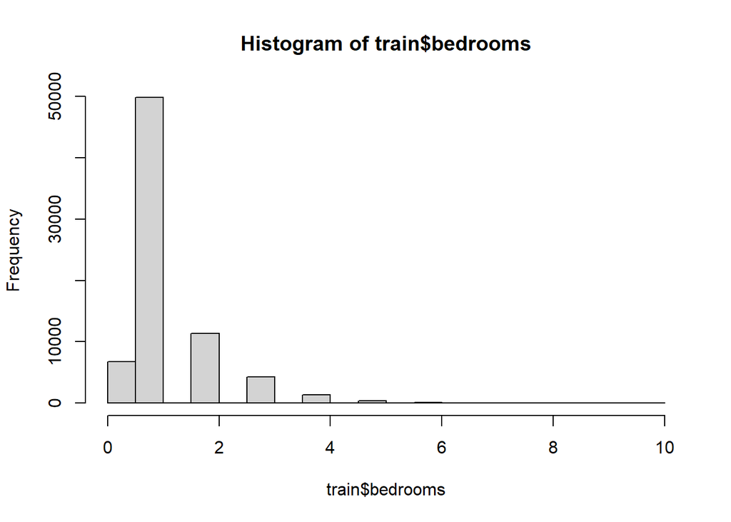

```r
hist(train$bedrooms)
```

There is highest number of single bedroom./